# *K*-means Clustering

###### By: Alan Flint

*k*-means is a very popular clustering technique that uses a distance metric to 'group' similar points together in *k* clusters. In this report, I will describe the algorithm in detail, show a few basic examples, introduce *k*-means++, and demonstrate common applications of the technique.

*The kmeans algoirthm used in this report is my implementation that I coded myself.*

###### The Algorithm

The basic idea of *k*-means is to randomly create k centroids, then assign points to the closest centroid and re-compute the centroids. The assigning and re-computing steps are done iteratively until the centroids do not change. The end result is each point in X belonging to a cluster that has other similar points. The psuedo code is below:

1. Randomly choose k points from X as the initial clusters
2. Iteratively:
   1. Compute the distance (Euclidean) from each point X to the k centroids
   2. Assign each point X to the cluster which it is closest to
   3. Compute the new centroid of each cluster
3. If the centroids do not change (within some tolerance), stop iterating
4. Return the clusters and the centroids

###### Basic Example

To see how this works, let's use a basic example in 2D. I generated some fake data with already well defined clusters: X and Y points on uniform (0,3), (3,6) and (6,9). Let's run the kmeans algorithm with k=3 clusters on the data and plot the points color coded by their cluster.

```python
def gen_data():
    x1, x2, x3 = np.random.uniform(0,3, size=50), np.random.uniform(3,6, size=50), \
                    np.random.uniform(6,9, size=50)
    y1, y2, y3 = np.random.uniform(0,3, size=50), np.random.uniform(3,6, size=50), \
                    np.random.uniform(6,9, size=50)
    X = np.concatenate((x1, x2, x3))
    Y = np.concatenate((y1, y2, y3))
    return np.array([X,Y]).T

X = gen_data()
```

```python
centroids, clusters = kmeans(X, 3)
```

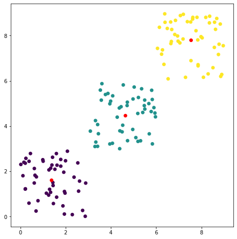

```python
plt.figure(figsize=(8,8))
plt.scatter(X[:,0], X[:,1], c=[j for i in range(len(X)) for j in range(len(clusters)) if i in clusters[j]])
plt.scatter(centroids[:,0], centroids[:,1], color='r')
plt.axis('square')
plt.show()
```

As you can see, three distinct clusters have been formed, each with the centroid (red points) at the cluster's center of mass. All the points have been correctly assigned to the closest centroid, and the result matches the intuition of the generated fake data.

###### A Pitfall: Random Initial Selection

However, the kmeans algorithm has one major pitfall: the initial random selection of the centroids. It's very possible that in a more complex dataset that the initial centroid selection isn't "good enough" and the clusters aren't that "good." Additionally, running the algorithm multiple times on the same data may give different clusters due to the random selection of centroids. Because of this, it's recommended to run kmeans several times and try different values for k to get the best solution. Another solution is to use kmeans++, which is a initial centroid identification algorithm designed to reduce those issues.

###### Introducing k-means++

The kmeans++ algorithm is as follows:

1. Randomly select the first centroid from X
2. For the remaining k-1 centroids,
   1. Compute the distance from each point in X to all the current centroids
   2. For each point in X, find the minimum of those computed distances
   3. The maximum of those minimums is the next centroid
3. Stop when you have k-centroids

###### Examples on Well Known Datasets

Let's see some examples of the algorithm in action on two well known datasets: breast cancer classification and iris classification (both from sklearn). I cluster the X values using my kmeans algorithm, take the mode of the labels for those X's in the cluster as the prediction, and compare my results to the true labels.

```python
from sklearn.datasets import load_breast_cancer
cancer = load_breast_cancer()
X = cancer.data
y = cancer.target
k=2
centroids, clusters = kmeans(X, k=k, centroids='kmeans++', tolerance=0.01)
likely_confusion_matrix(y, clusters)
```

```
clustering accuracy 0.8541
[[130  82]
 [  1 356]]
```

```python
from sklearn.datasets import load_iris
iris = load_iris()
X = iris.data
y = iris.target
k=3
centroids, clusters = kmeans(X, k=k, centroids='kmeans++', tolerance=0.01)
likely_confusion_matrix(y, clusters)
```

```
clustering accuracy 0.8933
[[50  0  0]
 [ 0 48  2]
 [ 0 14 36]]
```

I achieve above 85% accuracy for both the cancer and iris datasets.

###### A Cool Application: Color Compression of Images

One of the neatest things I've discovered in my exploration of kmeans is the ability to compress an image by clustering the colors into k groups, then reassigning each pixel the value of its cluster's centroid. There are 256 different shades possible in greyscale images, and 16,777,216 (256^3) possible colors in color images using RGB. You can use kmeans to cluster the colors and choose only k colors to represent your image. Let's look at a example.

Here I have a greyscale image of the Golden Gate Bridge in San Francisco

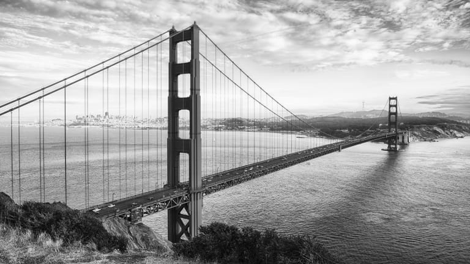

Now I will cluster the shades into 16 groups and 2 groups.

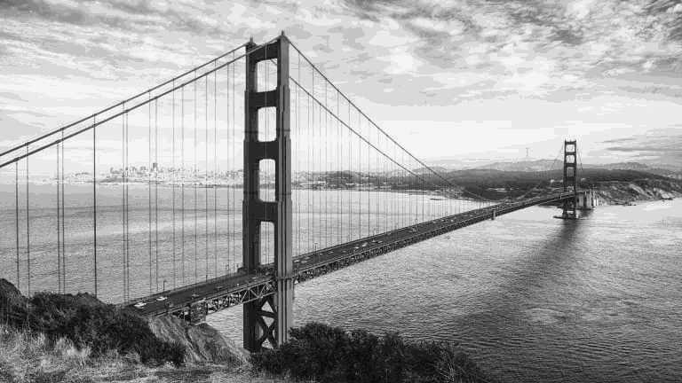

```python
k=16
centroids, clusters = kmeans(standard, k=k, centroids='kmeans++', tolerance=.1) # input is standarized image array
centroids = centroids * np.std(mat) + np.mean(mat)
X = reassign(standard, centroids, clusters)
img_ = Image.fromarray(X.reshape((r,c))).convert("L") # L means grayscale
img_
```

Wow! With just 16 shades, the image looks nearly the same as the full version with 256 shades. Let's have some fun and look at it with only 2 shades.

[figure not shown]

```python
k=2
centroids, clusters = kmeans(standard, k=k, centroids='kmeans++', tolerance=.1)
centroids
centroids = centroids * np.std(mat) + np.mean(mat)
X = reassign(standard, centroids, clusters)
img_ = Image.fromarray(X.reshape((r,c))).convert('L') # L means grayscale
img_
```

Pretty neat. Now let's see the color image and run kmeans on that.

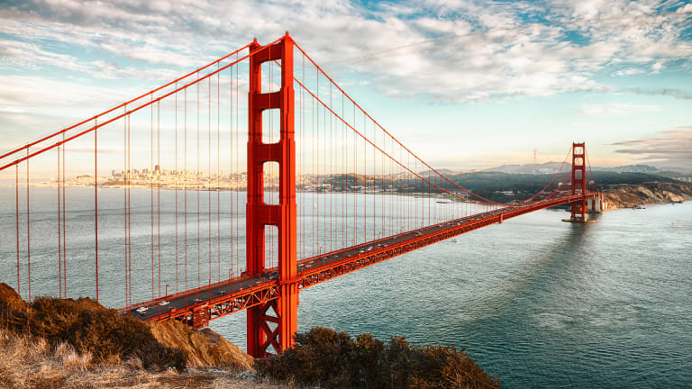

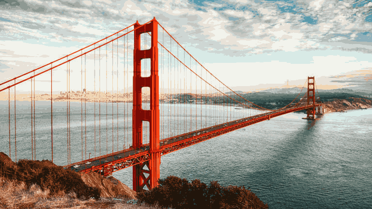

```python
k=32
centroids, clusters = kmeans(c_mat_std, k=k, centroids='kmeans++', tolerance=.1)
centroids = centroids * np.std(c_mat, axis=0) + np.mean(c_mat, axis=0)
X = reassign(c_mat_std, centroids, clusters)
img_ = Image.fromarray(X.reshape((r,c,3)))
img_
```

With only 32 unique colors (RGB values), the re-created image looks quite similar to the real thing. You obviously lose the fine details in the landscape, but overall the image looks great with only 32 colors. Now I'll show the color image with only 8 and 4 colors, respectively.

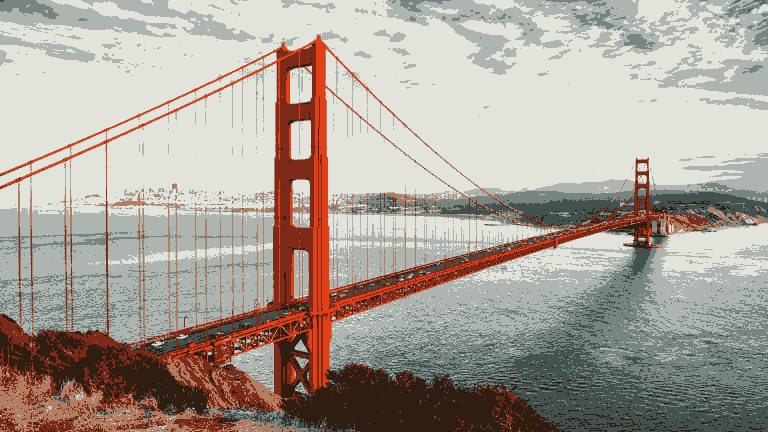

```python
k=8
centroids, clusters = kmeans(c_mat_std, k=k, centroids='kmeans++', tolerance=.1)
centroids = centroids * np.std(c_mat, axis=0) + np.mean(c_mat, axis=0)
X = reassign(c_mat_std, centroids, clusters)
img_ = Image.fromarray(X.reshape((r,c,3)))
img_
```

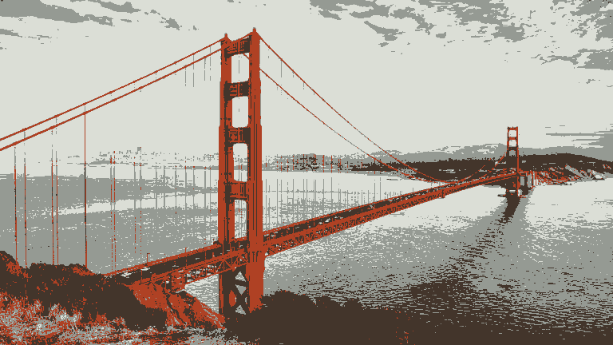

```python
k=4
centroids, clusters = kmeans(c_mat_std, k=k, centroids='kmeans++', tolerance=.1)
centroids = centroids * np.std(c_mat, axis=0) + np.mean(c_mat, axis=0)
X = reassign(c_mat_std, centroids, clusters)
img_ = Image.fromarray(X.reshape((r,c,3)))
img_
```

Both of these images look quite artistic; like technological, machine learning art.

###### Conclusion

In this report, I examined the kmeans clustering algorithm through explanation and examples. The algorithm iteratively computes k centroids and assigns points from X to each cluster until the centroids do not change. An extension of the algorithm is kmeans++, which smartly chooses the initial centroids using the maximum minimum distance trick. My kmeans++ implementation achieves fairly good accuracy on well-known classification data sets and can be used for color compression of images. kmeans can be applied to a wide variety of problems and it's a very useful algorithm to have in your tool-kit as a data scientist.